# The Reality of Instagram Usage and User Behaviour

## Introduction

Social media has become a major part of everyday life, especially among university students. For this project, I collected observational data related to Instagram usage and user behaviour. The purpose of this visual data story is to explore patterns in how people spend time on Instagram, the type of content they interact with the most, and how their usage changes over time.

The data was collected through a Google Form over multiple observations. Variables included the number of hours spent on Instagram, the type of content users saw most frequently, and the ways users interacted with posts they liked.

Although Instagram is often viewed as entertainment, the data reveals some interesting patterns in behaviour and engagement. Humanity somehow invented an app that compresses attention spans into fifteen-second clips and then decided this was a healthy daily ritual.

## Most Common Content Seen

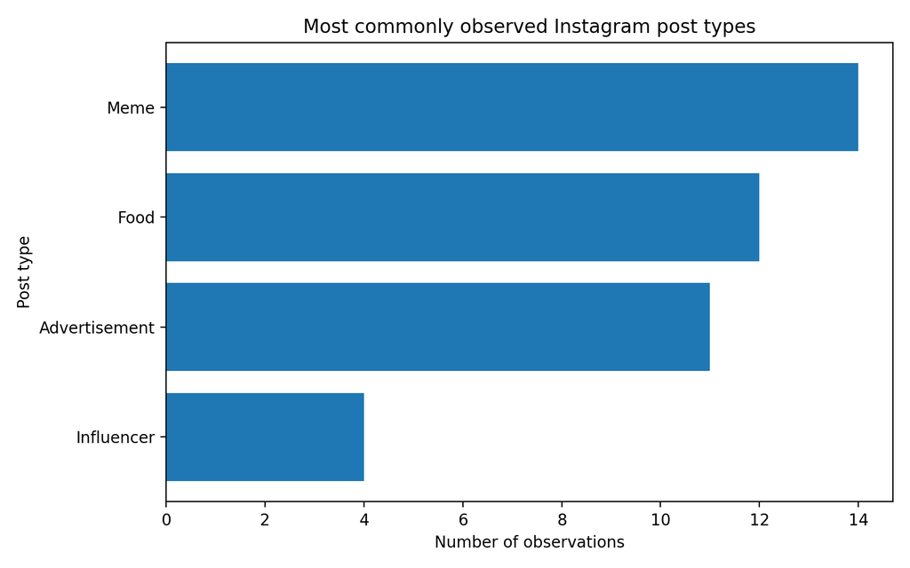

Bar chart showing the most common Instagram content types observed in the dataset

This visualisation compares the frequency of different types of Instagram content observed in the data collection process. The graph shows which content category appeared most often among users.

The bar chart format was chosen because it clearly displays differences between categories and makes it easy to compare counts visually. Colour was used consistently throughout the visual story to create a more aesthetic and connected presentation.

## Instagram Usage Over Time

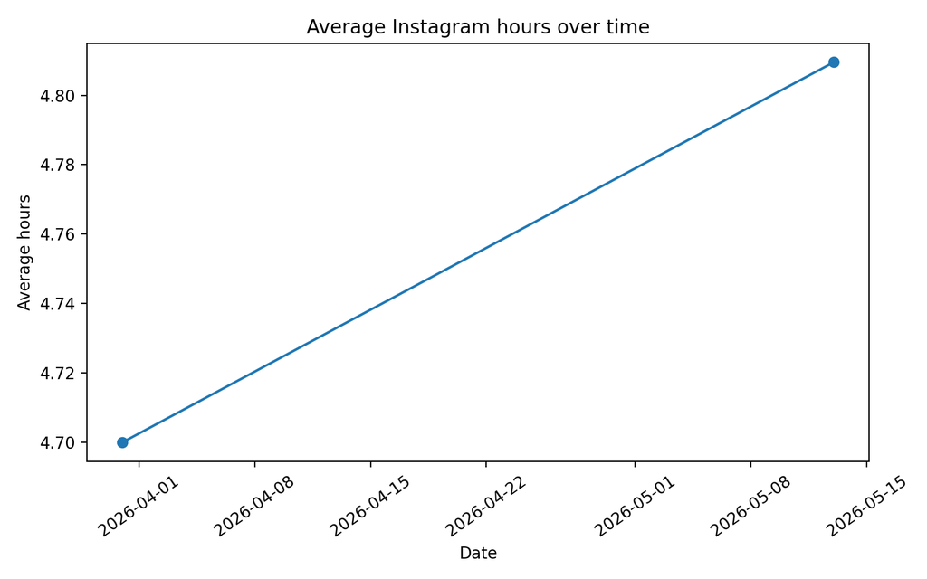

Line graph showing changes in Instagram usage hours over time based on timestamps

This visualisation uses timestamps converted into date-time values with the {lubridate} package in R. The graph tracks how Instagram usage changed over the data collection period.

## Interactions and Engagement

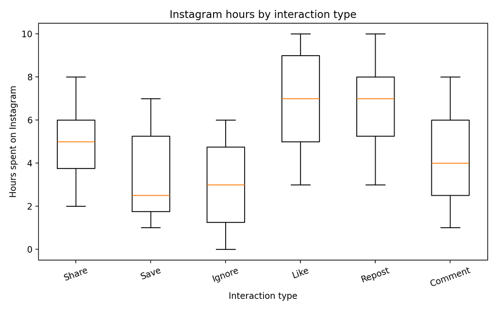

Boxplot comparing hours spent on Instagram based on interaction type

This final visualisation compares Instagram usage hours across different interaction behaviours. Examples include liking posts, sharing posts, commenting, or simply viewing content.

A boxplot was selected because it helps compare distributions and highlights variation between groups. Compared to bar charts, boxplots provide more statistical information, such as spread, median values, and potential outliers.

Overall, the data story demonstrates that Instagram usage is not only about time spent online, but also about the types of interactions and content that influence user behaviour.

## Conclusion

This project used observational logging and visual communication techniques to explore Instagram usage patterns. Through the use of multiple visualisations, colour themes, and data manipulation techniques in R, the project transformed raw observational data into a visual story that is easier to understand and interpret.

The visualisations reveal how content type, engagement behaviour, and time all influence Instagram usage. While the dataset is relatively small, it still provides meaningful insights into modern social media behaviour and highlights the usefulness of visual storytelling in communicating data.